# Effect of NOAA Storm Data for USA

Marco Dulog

December 29, 2017

## Synopsis

This report attempts to summarize the effect of Storm Damage on property people in the United States using Data from U.S. National Oceanic and Atmospheric Administration’s (NOAA) storm database from January 3, 1950, through November 30, 2011. The data in this database contains recorded weather events across the United States along with the number of injuries, deaths, and property damages.

### Property Damage Assumption for Weather Events

*Based upon data in the Results section, we can make the assumption that flood and storm-related events operate on a much wider area and can cause more devastation. However, with sufficient warning, the people have the opportunity to leave the affected area.*

### Population Damage Assumption for Weather Events

*Based upon data in the Results section, we can make the assumption that tornado-related events have little warning and people do not have the opportunity vacate the potentially affected area. Coupled with the destructive power of a tornado, this makes a very deadly combination*

## Data Processing

Data was loaded through the following file: https://d396qusza40orc.cloudfront.net/repdata%2Fdata%2FStormData.csv.bz2

The package SQLDF is heavily used in data preparation due to its simplicity and the author’s knowledge of SQL.

```r
require(sqldf)
require(lubridate)
setwd("c:/Users/Marco.Dulog/git/RepData_PeerAssessment2")
```

```r
if (!exists("ds")){
  ds <- read.csv(file=bzfile('StormData.csv.bz2'),strip.white = TRUE)
}
```

*Transformation* In a different dataset, evtypeUnique, was created to facilitate grouping. The main transformation was to group all the events, which were inconsistent, to 15 categories. This was done because data has 985 different event observations.

```r
evtypeUnique<-sqldf("SELECT evtype as eventType, count(1) as Counter FROM ds GROUP BY evtype")
evtypeUnique$CatGroup <-
  ifelse(grepl("TSTM|THUNDER|LIGHT|LIGN|STORM", evtypeUnique$eventType, ignore.case = TRUE),"STORM",
  ifelse(grepl("HAIL", evtypeUnique$eventType,ignore.case = TRUE),'HAIL',
  ifelse(grepl("HIGH WATER|FLOOD|FLOOOD|FLD", evtypeUnique$eventType,ignore.case = TRUE),'FLOOD',
  ifelse(grepl("TYPHOON|TSUN|HURRICANE|TROPICAL DEPRESSION", evtypeUnique$eventType,ignore.case = TRUE),'HURRICANE',
  ifelse(grepl("TORNAD|TORND|FUNNEL|TNADO|BURST", evtypeUnique$eventType,ignore.case = TRUE),'TORNADO',
  ifelse(grepl("RAIN|SHOWER|PRECIP|WET WE", evtypeUnique$eventType,ignore.case = TRUE),'RAIN',        ifelse(grepl("GLAZE|RECORD COLD|FREEZ|FROST|LOW TEMP|COLD|BLIZ|RECORD LOW|ICE|WINT|ICY|ICE|SNOW|SLEET", evtypeUnique$eventType,ignore.case = TRUE),'WINTER EVENTS',          ifelse(grepl("Temperature record|WARM|HEAT|RECORD HIGH|HIGH TEMP|WARM TEMP|RECORD TEMP|HOT|DROUGHT|DRY|WARMTH", evtypeUnique$eventType,ignore.case = TRUE),'HEAT EVENTS',                ifelse(grepl("WIND|DUST DEV", evtypeUnique$eventType,ignore.case = TRUE),'WIND',
  ifelse(grepl("FIRE", evtypeUnique$eventType,ignore.case = TRUE),'FIRE',
  ifelse(grepl("FOG", evtypeUnique$eventType,ignore.case = TRUE),'FOG',
  ifelse(grepl("AVALA", evtypeUnique$eventType,ignore.case = TRUE),'AVALANCHE',
  ifelse(grepl("MARINE|SWELL|SPOUT|TIDE|CURRENT|SURF|SEAS|COAST|WAVE",    evtypeUnique$eventType,ignore.case = TRUE),'MARINE EVENTS',
  ifelse(grepl("LAND|BEACH|MUD", evtypeUnique$eventType,ignore.case = TRUE),'ERROSION',                "OTHER")
                                                                                      )))))))))))))
```

### Event Damage to Population

Data processing determining storm affects to population is determined by capturing the fatalities and the injuries associated with the event type.

*Transformation* However, ranking the events in relation to population health damage and including death and injury in the same bucket did not seem appropriate. It was determined that an injury would be ranked less than a fatality by 1/3.

```r
dsPopDmg<-sqldf("
  SELECT upper(evtype) evtype
  , SUM(fatalities) as fatalities
  , SUM(injuries) as injuries
  , SUM((injuries * .3) + fatalities) as wgtdScore
  FROM ds
  WHERE (IfNull(injuries,0) > 0 or IfNull(fatalities,0) > 0)
  GROUP BY upper(evtype)")
```

Afterwards, the data is grouped by the category groups into a different dataset.

```r
dsGroupPop<-sqldf("
SELECT evt.CatGroup
, SUM(ds.fatalities) as fatalities
, SUM(ds.injuries) as injuries
, SUM(ds.wgtdScore) as wgtdScore
FROM dsPopDmg ds
JOIN evtypeUnique evt
ON ds.evtype = evt.EventType
WHERE 1 = 1
GROUP BY evt.[CatGroup]")
```

### Event Damage to Property

Data processing determining storm affects to property is determined by capturing the property damage and crop damage associated with event type. Ranking the weather events was easier since the damage to property was measured in dollars. The difficulty with this that the data associated with the damage values were spread across two different columns.

```r
dsPropDmg<-sqldf("
    SELECT evtype
    , (propDmgAmt * propdmgexp) as propertyDamage
    , (cropDmgAmt * cropDmgExp) as cropDamage
    FROM(
      SELECT upper(evtype) as evtype
      , IfNull(propdmg,0) as propDmgAmt
      , CASE
          WHEN lower(propdmgexp) = '1' THEN 10.00
          WHEN lower(propdmgexp) = '2' THEN 100.00
          WHEN lower(propdmgexp) = '3' THEN 1000.00
          WHEN lower(propdmgexp) = '4' THEN 10000.00
          WHEN lower(propdmgexp) = '5' THEN 100000.00
          WHEN lower(propdmgexp) = '6' THEN 1000000.00
          WHEN lower(propdmgexp) = '7' THEN 10000000.00
          WHEN lower(propdmgexp) = 'h' then 100.00
          WHEN lower(propdmgexp) = 'k' then 1000.00
          WHEN lower(propdmgexp) = 'm' then 1000000.00
          WHEN lower(propdmgexp) = 'b' then 1000000000.00
        ELSE 0
        END as propdmgexp
      , IfNull(cropdmg,0) as cropDmgAmt
      , CASE
          WHEN lower(cropdmgexp) = 'h' then 100.00
          WHEN lower(cropdmgexp) = 'k' then 1000.00
          WHEN lower(cropdmgexp) = 'm' then 1000000.00
          WHEN lower(cropdmgexp) = 'b' then 1000000000.00
        ELSE 0
        END as cropdmgexp
    FROM ds
      WHERE (IfNull(propdmg,0) > 0 or IfNull(cropdmg,0) > 0)
    ) v
  ")

dsPropertyDamage<-sqldf("
  SELECT evtype
  , SUM(propertyDamage) as propertyDamage
  , SUM(cropDamage) as cropDamage
  , SUM(propertyDamage + cropDamage) as combinedDamage
  FROM dsPropDmg
  GROUP BY evtype ")
```

Afterwards, the data is grouped by the category groups into a different dataset.

```r
dsGroupProp<-sqldf("
SELECT evt.CatGroup
, SUM(propertyDamage) propertyDamage
, SUM(cropDamage) cropDamage
, SUM(combinedDamage) combinedDamage
FROM dsPropertyDamage ds
JOIN evtypeUnique evt
on ds.evtype = evt.EventType
WHERE 1 = 1
GROUP BY evt.CatGroup
")
```

## Results

After constructing the grouping datasets (dsGroupPop - Population Damage, dsGroupProp - Property Damage) for weather events, the data associated with each set can be plotted to determine which weather events cause the most damage.

### Population Damge

Here is a sample of the population damage sorted descending by the weighted score.

```r
head(dsGroupPop[order(-dsGroupPop$wgtdScore),])
```

```
##         CatGroup fatalities injuries wgtdScore
## 13       TORNADO       5639    91439   33070.7
## 12         STORM       1997    18991    7694.3
## 7    HEAT EVENTS       3178     9247    5952.1
## 4          FLOOD       1556     8681    4160.3
## 15 WINTER EVENTS        791     3326    1788.8
## 14          WIND        465     1938    1046.4
```

Based upon this, we can see that tornado damage is by overall the most damaging of the weather events throughout the reported years. This is more evidant with a graph.

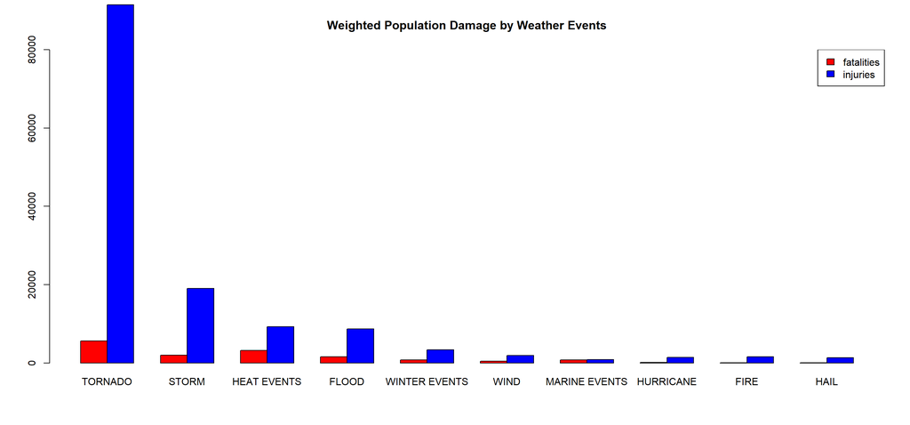

```r
mat10Pop<-sqldf("select fatalities, injuries from dsGroupPop order by wgtdScore desc LIMIT 10")
mat10PopHead<-sqldf("select CatGroup from dsGroupPop order by wgtdScore desc LIMIT 10")
barplot(t(mat10Pop)
        , names.arg=mat10PopHead$CatGroup
        , ylim = c(0,80000)
        , beside = TRUE
        , col=c("red", "blue")
        , main="Weighted Population Damage by Weather Events"
        )

legend("topright",names(mat10Pop), fill=c("red","blue"))
```

### Property Damage

Here is a sample of the property damage sorted decending by the combined damage of crops and property.

```r
head(dsGroupProp[order(-dsGroupProp$combinedDamage),])
```

```
##       CatGroup propertyDamage  cropDamage combinedDamage
## 4        FLOOD   168254303970 12388567200   180642871170
## 8    HURRICANE    85502209010  5516137800    91018346810
## 12       STORM    80351295320  7040214490    87391509810
## 13     TORNADO    57010914480   414977910    57425892390
## 6         HAIL    15736564220  3046887600    18783451820
## 7  HEAT EVENTS     1066431750 14877045280    15943477030
```

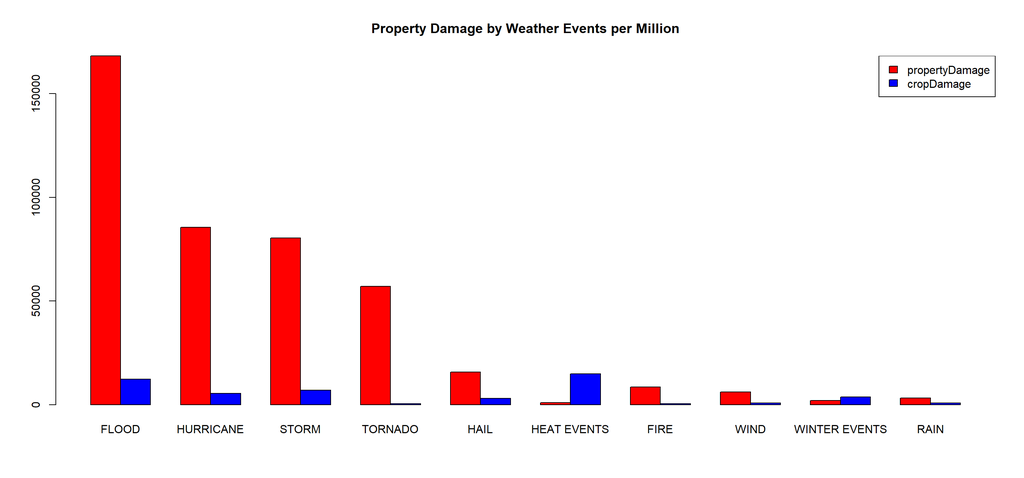

```r
mat10Prop<-sqldf("select (propertyDamage/1000000) as propertyDamage, (cropDamage/1000000) as cropDamage from dsGroupProp order by combinedDamage desc LIMIT 10")
mat10PropHead<-sqldf("select CatGroup from dsGroupProp order by combinedDamage desc LIMIT 10")
barplot(t(mat10Prop)
        , names.arg=mat10PropHead$CatGroup
        , beside = TRUE
        , col=c("red", "blue")
        , main="Property Damage by Weather Events per Million"
        )

legend("topright",names(mat10Prop), fill=c("red","blue"))
```